# Chick Weight Analysis

We have data which details the **weight** of different chicken bracketted by the type of **feed* they ate. The whole of the data is summarized below:

```
##      weight             feed
##  Min.   :108.0   casein   :12
##  1st Qu.:204.5   horsebean:10
##  Median :258.0   linseed  :12
##  Mean   :261.3   meatmeal :11
##  3rd Qu.:323.5   soybean  :14
##  Max.   :423.0   sunflower:12
```

[output not shown]

We summarize the data for **feed type** horsebean below:

```
##      weight             feed
##  Min.   :108.0   casein   : 0
##  1st Qu.:137.0   horsebean:10
##  Median :151.5   linseed  : 0
##  Mean   :160.2   meatmeal : 0
##  3rd Qu.:176.2   soybean  : 0
##  Max.   :227.0   sunflower: 0
```

We summarize the data for **feed type** linseed below:

```
##      weight             feed
##  Min.   :141.0   casein   : 0
##  1st Qu.:178.0   horsebean: 0
##  Median :221.0   linseed  :12
##  Mean   :218.8   meatmeal : 0
##  3rd Qu.:257.8   soybean  : 0
##  Max.   :309.0   sunflower: 0
```

We summarize the data for **feed type** meatmeal below:

```
##      weight             feed
##  Min.   :153.0   casein   : 0
##  1st Qu.:249.5   horsebean: 0
##  Median :263.0   linseed  : 0
##  Mean   :276.9   meatmeal :11
##  3rd Qu.:320.0   soybean  : 0
##  Max.   :380.0   sunflower: 0
```

We summarize the data for **feed type** soybean below:

```
##      weight             feed
##  Min.   :158.0   casein   : 0
##  1st Qu.:206.8   horsebean: 0
##  Median :248.0   linseed  : 0
##  Mean   :246.4   meatmeal : 0
##  3rd Qu.:270.0   soybean  :14
##  Max.   :329.0   sunflower: 0
```

We summarize the data for **feed type** sunflower below:

```
##      weight             feed
##  Min.   :226.0   casein   : 0
##  1st Qu.:312.8   horsebean: 0
##  Median :328.0   linseed  : 0
##  Mean   :328.9   meatmeal : 0
##  3rd Qu.:340.2   soybean  : 0
##  Max.   :423.0   sunflower:12
```

We now summarize the entirey of the data in a graph below:

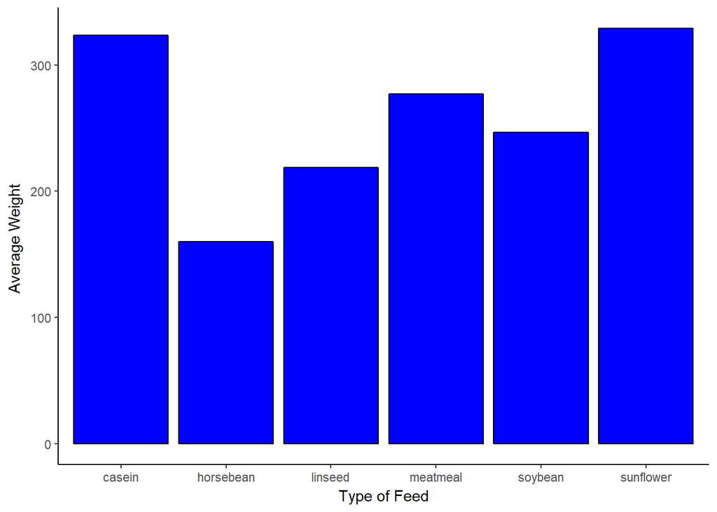

To investigate whether feeding chickens different **feed** may have had an affect on their **weight**, we test whether the **weights** of chickens fed sunflower and soybeans are statistically different. To do so, we first construct null and alternate hypotheses.

*Null Hypothesis: The* **weight** *of chickens fed sunflower and soybeans are not significantly different.*

*Alternate Hypothesis: The* **weight** *of chickens fed sunflower and soybeans are significantly different.*

We performed likelihood ratio test to compare the **weights** of chickens fed sunflower and soybeans and arrived at a p-value of approximately 0.000233458. This is small enough to reject the null hypothesis, so we project that that the **weights** of chickens fed soybeans and sunflowers are significantly different.